# Analyzing Potential Predictors for Median House Value in Philadelphia

Milan Brito

2026-03-01

# The Problem

We are using OLS regression analysis to identify any relationships between median house value and other neighborhood characteristics, such as educational attainment, vacancy rates, housing typology, median household income, poverty level, and median house value. The data we are using comes from the 2000 U.S. Census in Philadelphia, Pennsylvania.

OLS regression has several assumptions, which are:

1. Linear relationship between dependent variable and each of the independent variables
2. Normality of residuals
3. Homoscedasticity
4. Independence of observations
5. No multicollinearity
6. No fewer than 10 observations per independent variable

We will analyze our regression model to check if it follows these assumptions.

**Note:** This analysis is a condensed sample from a 30-page report. It is meant to serve as a brief summary of the full data analysis.

## Data Cleaning

We cleaned the original 1,816 observations to compile a new dataset with only 1,700 observations. The data cleaning process included removing block groups with less than 40 residents, blocks groups where there are no housing units, and block groups where the median house value is lower than $10,000.

*This satisfies OLS regression assumption #6.*

```r
# Getting data from 2000 Census
data_orig <- get_decennial(geography = "block group",
                           state = "PA",
                           county = "Philadelphia",
                           variables = c("H076001", "P037015", "P037032",
                                         "H002003", "H030002", "P089002",
                                         "P053001", "P001001", "H001001"),
                           year = 2000,
                           output = "wide",
                           geometry = TRUE,
                           keep_geo_vars = TRUE,
                           progress_bar = FALSE) %>%
  mutate(PCTBACHMOR = P037015 + P037032) %>%
  rename(MEDHVAL = H076001, PCTVACANT = H002003, PCTSINGLES = H030002,
         NBELPOV100 = P089002, MEDHHINC = P053001, TOTPOP = P001001,
         TOTUNITS = H001001, NAME = NAME.y) %>%
  dplyr::select(GEOID, NAME, MEDHVAL, PCTBACHMOR, PCTVACANT, PCTSINGLES,
                    NBELPOV100, MEDHHINC, TOTPOP, TOTUNITS, geometry)

# Cleaning data
data_spatial <- data_orig %>%
  filter(TOTPOP >= 40) %>%
  filter(TOTUNITS > 0) %>%
  filter(MEDHVAL >= 10000)

data <- as_tibble(data_spatial) %>%
  dplyr::select(!geometry)
```

# Exploratory Data Analysis

Let’s look at the summary statistics for each of the variables we identified: median house value (`MEDHVA`L), percentage of vacant houses (`PCTVACANT`), percentage of single house units (`PCTSINGLES`), percentage of individuals with bachelor’s degrees or higher (`PCTBACHMOR`), and number of households living in poverty (`NBELPOV100`).

## Variable Distributions

First, we’ll visualize the distributions of each variable.

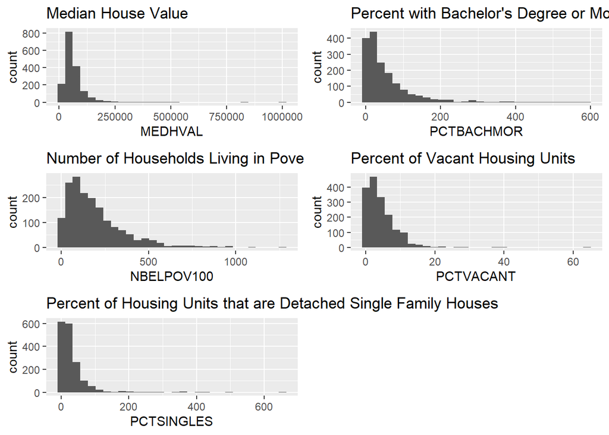

## Mean and Standard Deviation

Now let’s look at the mean and standard deviation of each variable.

Variable Means & Standard Deviations

| Variable | Mean | SD |
| --- | --- | --- |
| MEDHVAL | 65980.53 | 60347.69 |
| PCTBACHMOR | 56.48 | 75.38 |
| PCTVACANT | 4.39 | 4.18 |
| PCTSINGLES | 31.11 | 49.3 |
| NBELPOV100 | 188.68 | 163.54 |
| MEDHHINC | 31660.79 | 16296.07 |

## Logarithmic Transformations

We’ll explore applying a logarithmic transformation to variables. This is done to make the variables normally distributed to satisfy the assumptions of OLS regression. If any variable contained values equal to zero, then we add 1 before applying the logarithmic transformation. Any variable on which a log transformation was applied was designated by “LN” in front of the original variable name.

```r
data <- data %>%
  mutate(LNMEDHVAL = log(MEDHVAL), LNPCTBACHMOR = log(1 + PCTBACHMOR),
         LNNBELPOV100 = log(1 + NBELPOV100), LNPCTVACANT = log(1 + PCTVACANT),
         LNPCTSINGLES = log(1 + PCTSINGLES))
```

Here are the distributions of each transformed variable.

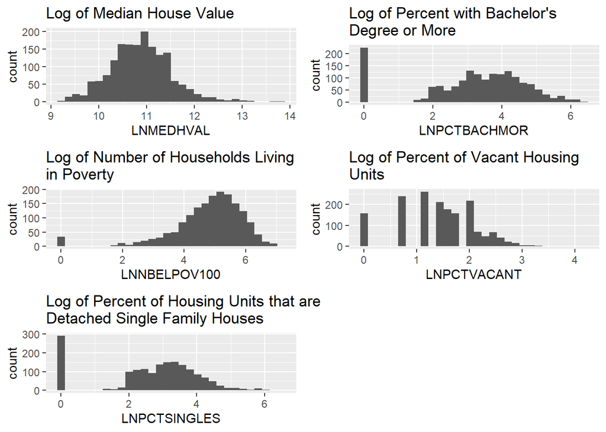

We’ll use the transformed variables for Median House Value (`LNMEDHVAL`) and Number of Households Living in Poverty (`LNNBELPOV100`). Since the other variables have zero-inflated distributions, we will use the untransformed versions (`PCTBACHMOR`, `PCTVACANT`, and `PCTSINGLES`).

## Relationships Between Dependent and Independent Variables

Let’s see if the relationships between the dependent and independent variables are linear.

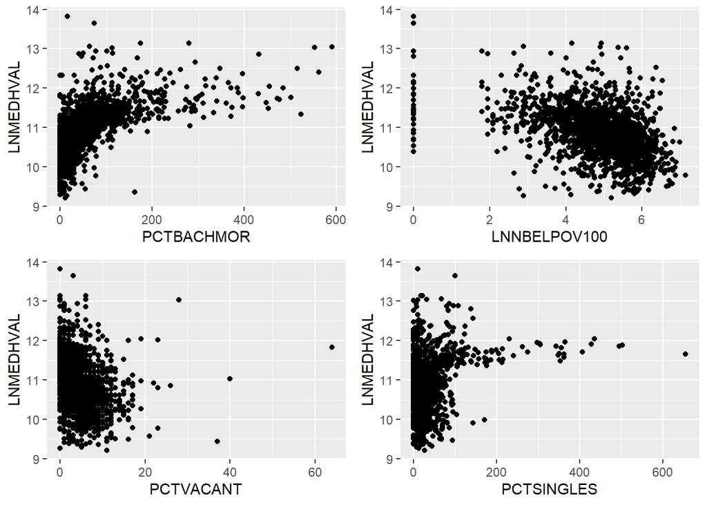

*None of these plots demonstrate a linear relationship, which violates OLS regression assumption #1.*

## Checking for Multicollinearity

We’ll analyze the Pearson correlations between all the independent variables to ensure there’s no multicollinearity.

```r
pearson <- cor(data[,c(6,7,4,11)], method = "pearson")

kable(pearson, caption = "Correlation Matrix for Independent Variables")
```

Correlation Matrix for Independent Variables

|  | PCTSINGLES | NBELPOV100 | PCTBACHMOR | LNMEDHVAL |
| --- | --- | --- | --- | --- |
| PCTSINGLES | 1.0000000 | 0.0258650 | 0.3141039 | 0.2564638 |
| NBELPOV100 | 0.0258650 | 1.0000000 | -0.0563502 | -0.3925057 |
| PCTBACHMOR | 0.3141039 | -0.0563502 | 1.0000000 | 0.5994906 |
| LNMEDHVAL | 0.2564638 | -0.3925057 | 0.5994906 | 1.0000000 |

*The low Pearson correlation values indicate that there is no multicollinearity, satisfying OLS regression assumption #5.*

## Spatial Analysis

We’ll use our `data_spatial` object to see these variables spatially.

```r
data_spatial <- data_spatial %>%
  mutate(LNMEDHVAL = log(MEDHVAL), LNPCTBACHMOR = log(1 + PCTBACHMOR),
         LNNBELPOV100 = log(1 + NBELPOV100), LNPCTVACANT = log(1 + PCTVACANT),
         LNPCTSINGLES = log(1 + PCTSINGLES))
```

Let’s look at chloropleth maps of each variable.

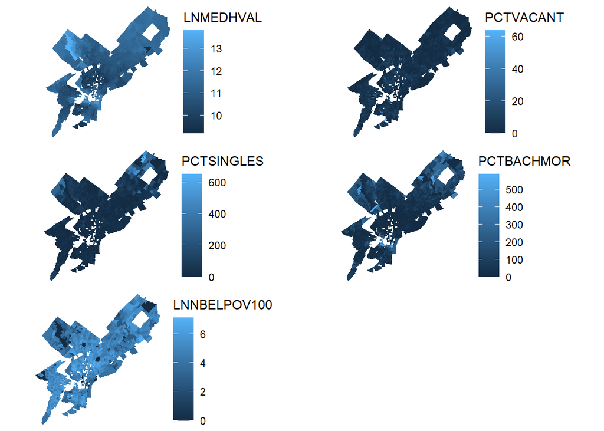

# Regression Analysis

We’ll run a regression where `LNMEDHVAL` is the dependent variable and `PCTVACANT`, `PCTSINGLES`, `PCTBACHMOR`, and `LNNBELPOV100` are the independent variables.

```r
reg1 <- lm(LNMEDHVAL ~ PCTVACANT + PCTSINGLES + PCTBACHMOR + LNNBELPOV100,
           data = data)
```

Let’s look at the summary and ANOVA tables.

```r
summary(reg1)
```

```
##
## Call:
## lm(formula = LNMEDHVAL ~ PCTVACANT + PCTSINGLES + PCTBACHMOR +
##     LNNBELPOV100, data = data)
##
## Residuals:
##      Min       1Q   Median       3Q      Max
## -1.84871 -0.22293  0.03746  0.22485  2.11582
##
## Coefficients:
##                Estimate Std. Error t value             Pr(>|t|)
## (Intercept)  11.6195864  0.0458874 253.220 < 0.0000000000000002 ***
## PCTVACANT    -0.0179723  0.0026936  -6.672       0.000000000034 ***
## PCTSINGLES    0.0007535  0.0002205   3.417             0.000648 ***
## PCTBACHMOR    0.0048378  0.0001443  33.535 < 0.0000000000000002 ***
## LNNBELPOV100 -0.2003334  0.0097562 -20.534 < 0.0000000000000002 ***
## ---
## Signif. codes:  0 '***' 0.001 '**' 0.01 '*' 0.05 '.' 0.1 ' ' 1
##
## Residual standard error: 0.425 on 1695 degrees of freedom
## Multiple R-squared:  0.5469, Adjusted R-squared:  0.5458
## F-statistic: 511.5 on 4 and 1695 DF,  p-value: < 0.00000000000000022
```

```r
anova(reg1)
```

```
## Analysis of Variance Table
##
## Response: LNMEDHVAL
##                Df  Sum Sq Mean Sq F value                Pr(>F)
## PCTVACANT       1  40.967  40.967  226.77 < 0.00000000000000022 ***
## PCTSINGLES      1  42.522  42.522  235.38 < 0.00000000000000022 ***
## PCTBACHMOR      1 209.956 209.956 1162.19 < 0.00000000000000022 ***
## LNNBELPOV100    1  76.172  76.172  421.64 < 0.00000000000000022 ***
## Residuals    1695 306.211   0.181
## ---
## Signif. codes:  0 '***' 0.001 '**' 0.01 '*' 0.05 '.' 0.1 ' ' 1
```

## Residuals

We’ll save the fitted values, residuals, and standardized residuals to visualize our standardized residuals vs. predicted values.

```r
data <- data %>%
  mutate(predvals = fitted(reg1),
         resids = residuals(reg1),
         stdres = rstandard(reg1))
```

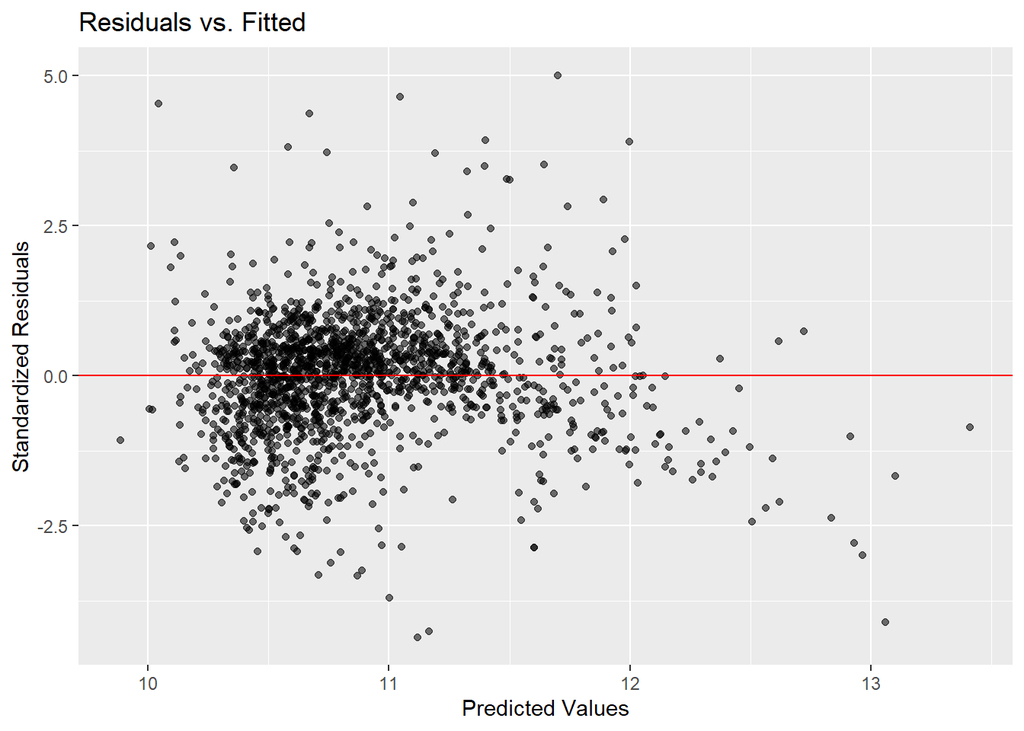

*This satisfies OLS regression assumption #3.*

Now, let’s look at a histogram of our residuals.

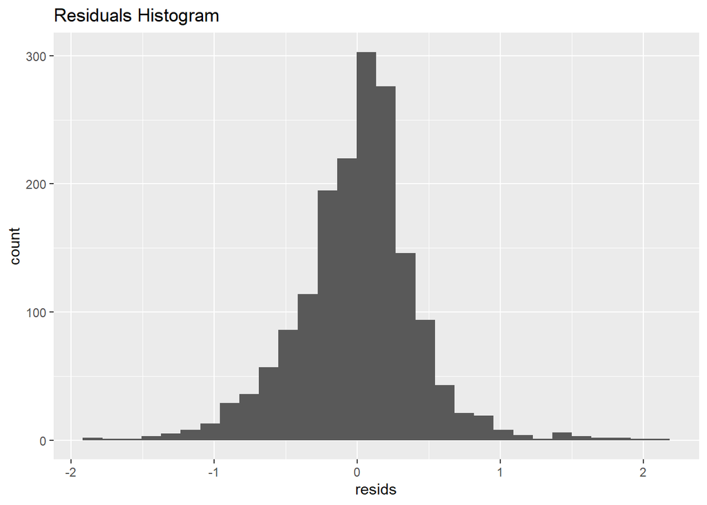

The residuals have a relatively normal distribution.

*This satisfies OLS regression assumption #2.*

## Checking for Spatial Dependencies

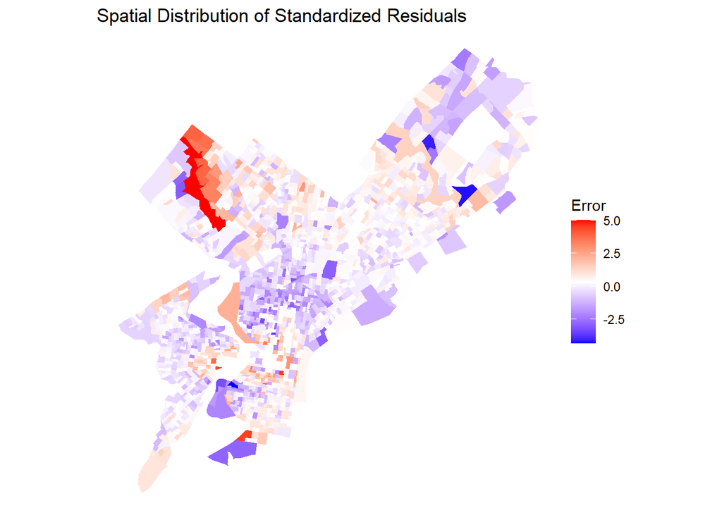

Another way of understanding spatial autocorrelation is through calculating Moran’s I. Moran’s I is within the range of -1 to 1, with -1 indicating negative correlation, 1 indicating positive correlation, and 0 indicating a random spatial pattern.

```r
# Identifying neighbors
coords <- st_coordinates(st_centroid(data_spatial))
nb <- knn2nb(knearneigh(coords, k=5))
weights <- nb2listw(nb, style="W")

# Calculating Moran's I
moran_test <- moran.mc(
  data$resids,
  weights,
  nsim = 999)

# Moran's I
moran_test$statistic
```

```
## statistic
## 0.3644015
```

```r
# p-value
moran_test$p.value
```

```
## [1] 0.001
```

The results of Moran’s I indicate that there is significant clustering in our residuals, which means there is spatial autocorrelation present in our data and that observations are not independent of each other.

*This violates OLS assumption #4.*

# Discussion